# Анализа геохемијског састава стена

Марко Николић E2 47-2024

# Анализа геохемијског састава стена

## Скуп података

Скуп података потиче из базе података GEOROC (Geochemistry of Rocks of the Oceans and Continents), доступне на сајту https://georoc.eu. Подаци садрже информације о концентрацијама хемијских елемената/једињења, изотопске односе као и аналитичке старости за стене, минерале и инклузије. Уз хемијске податке, сваки узорак садржи и податке попут географског положаја и податке о тектонском окружењу.

Подаци су на сајту организовани према тектонским окружењима, и појединачно су преузети и скупљени на једно место за потребе пројекта. Укупна величина скупа износи нешто више од 3 GB.

[figure not shown]

## Технологије

За потребе овог пројекта коришћен је програмски језик R.

[figure not shown]

## Припрема података

За почетак је потребно да очистимо податке. Процес чишћења података приказан је у овој секцији.

1. Пре чишћења података потребно је да наведемо све потребне библиотеке.

```r
library(tidyverse)
library(randomForest)
```

2. Затим, учитавамо податке. Подаци су преузети у локални директоријум и подељени су на десетине фајлова. Код испод учитава податке из свих CSV фајлова и спаја их у један јединствени скуп података.

```r
files <- list.files("../data/rocks", recursive = TRUE, full.names = TRUE)
files <- files[grepl("\\.csv$", files)]

raw_data_parts <- lapply(files, read.csv)
raw_data <- do.call(rbind, raw_data_parts)
names(raw_data) <- sub("\\.+$", "", names(raw_data))
```

3. Овај скуп података садржи велики број обележја (преко 150). За потребе овог пројекта, око 100 обележја је остављено у скупу података, а остатак се одбацује. Преостала обележја обухватају следеће информације:
   - Географска обележја:
     - LAND.OR.SEA - припадност копненом или морском тектонском окружењу.
     - TECTONIC.SETTING - припадност једном од 11 поткатегороја тектонских окружења (другачија подела од море/копно поделе).
   - Хемијска обележја:
     - Информације о оксидима - процентуални удео одређеног оксида у укупној маси стене.
     - Информације о елементима у траговима - број честица неког елемента на милион честица.

```r
geographical_columns <- c(
  "LAND.OR.SEA",
  "TECTONIC.SETTING"
)
oxide_columns <- c(
  "SIO2.WT",
  "TIO2.WT",
  "B2O3.WT",
  "AL2O3.WT",
  "CR2O3.WT",
  "FE2O3.WT",
  "FEO.WT",
  "CAO.WT",
  "MGO.WT",
  "MNO.WT",
  "NIO.WT",
  "K2O.WT",
  "NA2O.WT",
  "P2O5.WT",
  "H2O.WT",
  "CO2.WT",
  "CO1.WT",
  "F.WT",
  "CL.WT",
  "CL2.WT",
  "OH.WT",
  "CH4.WT",
  "SO2.WT",
  "SO3.WT",
  "SO4.WT",
  "S.WT",
  "O.WT"
)
trace_element_columns <- c(
  "LI.PPM",
  "BE.PPM",
  "B.PPM",
  "C.PPM",
  "CO2.PPM",
  "F.PPM",
  "NA.PPM",
  "MG.PPM",
  "AL.PPM",
  "P.PPM",
  "S.PPM",
  "CL.PPM",
  "K.PPM",
  "CA.PPM",
  "SC.PPM",
  "TI.PPM",
  "V.PPM",
  "CR.PPM",
  "MN.PPM",
  "FE.PPM",
  "CO.PPM",
  "NI.PPM",
  "CU.PPM",
  "ZN.PPM",
  "GA.PPM",
  "GE.PPM",
  "AS.PPM",
  "SE.PPM",
  "BR.PPM",
  "RB.PPM",
  "SR.PPM",
  "Y.PPM",
  "ZR.PPM",
  "NB.PPM",
  "MO.PPM",
  "RU.PPM",
  "RH.PPM",
  "PD.PPM",
  "AG.PPM",
  "CD.PPM",
  "IN.PPM",
  "SN.PPM",
  "SB.PPM",
  "TE.PPM",
  "I.PPM",
  "CS.PPM",
  "BA.PPM",
  "LA.PPM",
  "CE.PPM",
  "PR.PPM",
  "ND.PPM",
  "SM.PPM",
  "EU.PPM",
  "GD.PPM",
  "TB.PPM",
  "DY.PPM",
  "HO.PPM",
  "ER.PPM",
  "TM.PPM",
  "YB.PPM",
  "LU.PPM",
  "HF.PPM",
  "TA.PPM",
  "W.PPM",
  "RE.PPM",
  "OS.PPM",
  "IR.PPM",
  "PT.PPM",
  "AU.PPM",
  "HG.PPM",
  "TL.PPM",
  "PB.PPM",
  "BI.PPM",
  "TH.PPM",
  "U.PPM"
)
selected_columns <- c(geographical_columns, oxide_columns, trace_element_columns)

cleaned_data <- raw_data[, selected_columns]
```

4. Преостале податке је потребно пречистити. За почетак је потребно обратити пажњу на обележје LAND.OR.SEA:
   - брисање редова недостајућим вредностима у овој колони (NA или ““).
   - претварање малих слова у велика како не бисмо имали различите вредности за исту информацију.
   - пребацивање вредности из скупа у разумљивије вредности (LAND/SEA).

```r
cleaned_data$LAND.OR.SEA <- as.factor(cleaned_data$LAND.OR.SEA)
levels(cleaned_data$LAND.OR.SEA)
```

```
## [1] ""    "Sae" "SAE" "Saq" "SAQ"
```

```r
cleaned_data <- filter(cleaned_data, !is.na(LAND.OR.SEA))
cleaned_data <- filter(cleaned_data, LAND.OR.SEA != "")
cleaned_data$LAND.OR.SEA <- toupper(cleaned_data$LAND.OR.SEA)
cleaned_data$LAND.OR.SEA <- ifelse(cleaned_data$LAND.OR.SEA == "SAE", "LAND", "SEA")

cleaned_data$LAND.OR.SEA <- as.factor(cleaned_data$LAND.OR.SEA)
levels(cleaned_data$LAND.OR.SEA)
```

```
## [1] "LAND" "SEA"
```

5. Слично радимо и за обележје TECTONIC.SETTING:
   - брисање редова недостајућим вредностима у овој колони (NA или ““).
   - претварање малих слова у велика како не бисмо имали различите вредности за исту информацију.

```r
cleaned_data$TECTONIC.SETTING <- as.factor(cleaned_data$TECTONIC.SETTING)
levels(cleaned_data$TECTONIC.SETTING)
```

```
##  [1] "ARCHEAN CRATON (INCLUDING GREENSTONE BELTS)"
##  [2] "COMPLEX VOLCANIC SETTINGS"
##  [3] "CONTINENTAL FLOOD BASALT"
##  [4] "convergent margin"
##  [5] "CONVERGENT MARGIN"
##  [6] "INTRAPLATE VOLCANICS"
##  [7] "OCEAN ISLAND"
##  [8] "OCEAN-BASIN FLOOD BASALT"
##  [9] "OCEANIC PLATEAU"
## [10] "RIFT VOLCANICS"
## [11] "SEAMOUNT"
## [12] "SUBMARINE RIDGE"
```

```r
cleaned_data <- filter(cleaned_data, !is.na(TECTONIC.SETTING))
cleaned_data <- filter(cleaned_data, TECTONIC.SETTING != "")
cleaned_data$TECTONIC.SETTING <- toupper(cleaned_data$TECTONIC.SETTING)

cleaned_data$TECTONIC.SETTING <- as.factor(cleaned_data$TECTONIC.SETTING)
levels(cleaned_data$TECTONIC.SETTING)
```

```
##  [1] "ARCHEAN CRATON (INCLUDING GREENSTONE BELTS)"
##  [2] "COMPLEX VOLCANIC SETTINGS"
##  [3] "CONTINENTAL FLOOD BASALT"
##  [4] "CONVERGENT MARGIN"
##  [5] "INTRAPLATE VOLCANICS"
##  [6] "OCEAN ISLAND"
##  [7] "OCEAN-BASIN FLOOD BASALT"
##  [8] "OCEANIC PLATEAU"
##  [9] "RIFT VOLCANICS"
## [10] "SEAMOUNT"
## [11] "SUBMARINE RIDGE"
```

6. Хемијске колоне се чисте групно. За њих се не бришу редови са недостајућим вредностима јер сваки ред има макар једну због великог броја обележја:
   - претварање обележја у нумеричке вредности.
   - брисање редова где неки од процената оксида превазилази 100.
   - брисање редова где неки од броја честица елемената у траговима оксида превазилази 1000000.
   - брисање редова где је неко од џемијских обележја мање од 0.
   - брисање редова где сума процената оксида превазилази 100.
   - брисање редова где сума броја честица елемената у траговима превазилази 1000000.

```r
chemical_columns <- c(oxide_columns, trace_element_columns)
cleaned_data[chemical_columns] <- lapply(cleaned_data[chemical_columns], as.numeric)

bad_values_indicies <- which(apply(cleaned_data[oxide_columns], 1, function(r) any(r > 100, na.rm = TRUE)))
length(bad_values_indicies)
```

```
## [1] 1
```

```r
cleaned_data <- cleaned_data[-bad_values_indicies, ]

bad_values_indicies <- which(apply(cleaned_data[trace_element_columns], 1, function(r) any(r > 1000000, na.rm = TRUE)))
length(bad_values_indicies)
```

```
## [1] 9
```

```r
cleaned_data <- cleaned_data[-bad_values_indicies, ]

bad_values_indicies <- which(apply(cleaned_data[chemical_columns], 1, function(r) any(r < 0, na.rm = TRUE)))
length(bad_values_indicies)
```

```
## [1] 326
```

```r
cleaned_data <- cleaned_data[-bad_values_indicies, ]

bad_values_indicies <- which(rowSums(cleaned_data[oxide_columns], na.rm = TRUE) > 100)
length(bad_values_indicies)
```

```
## [1] 32608
```

```r
cleaned_data <- cleaned_data[-bad_values_indicies, ]

bad_values_indicies <- which(rowSums(cleaned_data[trace_element_columns], na.rm = TRUE) > 1000000)
length(bad_values_indicies)
```

```
## [1] 71
```

```r
cleaned_data <- cleaned_data[-bad_values_indicies, ]
```

7. Следеће што је потребно урадити је испитивање недостајућих вредности:
   - обележја LAND.OR.SEA и TECTONIC.SETTING немају недостајућих вредности, већ су очишћене.
   - Хемијска обележја имају варирајући проценат недостајућих вредности.

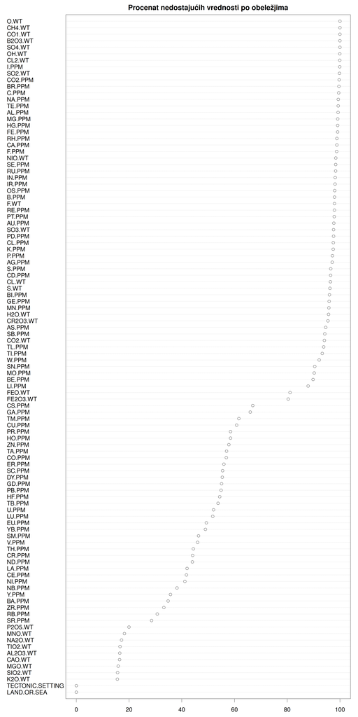

```r
missing_values_stats <- colMeans(is.na(cleaned_data)) * 100
missing_values_stats <- sort(missing_values_stats, decreasing = FALSE)

dotchart(
  missing_values_stats,
  main = "Procenat nedostajućih vrednosti po obeležjima",
  xlab = "Procenat NA (%)",
  cex = 2
)
```

8. Уколико је потребно, могуће је испитати и проценат недостајућих вредности за хемијска обележја груписано по обележју LAND.OR.SEA.

```r
missing_values_stats_by_tectonic_setting <- sapply(chemical_columns, function(c) {
  tapply(
    is.na(cleaned_data[[c]]),
    cleaned_data$LAND.OR.SEA,
    mean
  )
}) * 100

missing_values_stats_by_tectonic_setting <- t(missing_values_stats_by_tectonic_setting)
missing_values_stats_by_tectonic_setting
```

```
##              LAND       SEA
## SIO2.WT  15.42882  18.56597
## TIO2.WT  16.43865  18.49372
## B2O3.WT  99.99496 100.00000
## AL2O3.WT 16.31493  18.62537
## CR2O3.WT 95.29976  97.42799
## FE2O3.WT 79.95322  86.12850
## FEO.WT   80.56519  87.65694
## CAO.WT   16.23524  18.72170
## MGO.WT   15.72952  17.99441
## MNO.WT   18.07226  20.60335
## NIO.WT   98.39431  98.74450
## K2O.WT   15.43128  17.36666
## NA2O.WT  17.04128  18.50014
## P2O5.WT  19.61732  24.63475
## H2O.WT   95.90054  92.72389
## CO2.WT   94.19007  92.88444
## CO1.WT   99.99791  99.96307
## F.WT     97.99018  97.04428
## CL.WT    96.64854  93.01127
## CL2.WT   99.92928  99.86353
## OH.WT    99.94650  99.86353
## CH4.WT   99.99963  99.97271
## SO2.WT   99.89030  98.93234
## SO3.WT   97.57117  97.73625
## SO4.WT   99.99287 100.00000
## S.WT     96.38683  93.90553
## O.WT     99.99951 100.00000
## LI.PPM   87.93235  87.93950
## BE.PPM   89.42195  94.85117
## B.PPM    98.00863  97.11332
## C.PPM    99.51569  99.74473
## CO2.PPM  99.86779  97.75230
## F.PPM    98.79475  98.11675
## NA.PPM   99.32555  99.87638
## MG.PPM   99.11795  99.65803
## AL.PPM   99.25053  99.79129
## P.PPM    97.08846  98.10391
## S.PPM    96.73229  93.48971
## CL.PPM   97.78639  93.61494
```

[output cut: 48 more lines]

```
## LU.PPM   50.74517  64.76255
## HF.PPM   53.53532  65.56048
## TA.PPM   55.98666  70.12491
## W.PPM    91.75915  96.96079
## RE.PPM   97.83178  98.99978
## OS.PPM   97.93410  99.17638
## IR.PPM   98.07172  99.16835
## PT.PPM   97.74458  99.06400
## AU.PPM   97.53341  99.56170
## HG.PPM   99.07257  99.97271
## TL.PPM   93.69407  95.70208
## PB.PPM   54.07978  65.76759
## BI.PPM   95.79207  99.10734
## TH.PPM   43.13498  60.87082
## U.PPM    50.95596  66.37126
```

9. Уколико је потребно, могуће је испитати и проценат недостајућих вредности за хемијска обележја груписано по обележју TECTONIC.SETTING.

```r
missing_values_stats_by_tectonic_setting <- sapply(chemical_columns, function(c) {
  tapply(
    is.na(cleaned_data[[c]]),
    cleaned_data$TECTONIC.SETTING,
    mean
  )
}) * 100

missing_values_stats_by_tectonic_setting <- t(missing_values_stats_by_tectonic_setting)
missing_values_stats_by_tectonic_setting
```

```
##          ARCHEAN CRATON (INCLUDING GREENSTONE BELTS) COMPLEX VOLCANIC SETTINGS
## SIO2.WT                                     20.01672                  20.17486
## TIO2.WT                                     18.99780                  20.21858
## B2O3.WT                                    100.00000                 100.00000
## AL2O3.WT                                    19.07947                  20.21858
## CR2O3.WT                                    91.68141                  98.49180
## FE2O3.WT                                    86.99127                  53.35519
## FEO.WT                                      88.42048                  53.15847
## CAO.WT                                      19.64532                  20.15301
## MGO.WT                                      17.14858                  20.17486
## MNO.WT                                      20.81591                  20.59016
## NIO.WT                                      97.19603                  99.82514
## K2O.WT                                      20.44840                  18.68852
## NA2O.WT                                     20.14312                  19.84699
## P2O5.WT                                     23.65294                  21.04918
## H2O.WT                                      97.79299                  96.43716
## CO2.WT                                      94.37649                  96.41530
## CO1.WT                                     100.00000                 100.00000
## F.WT                                        99.64999                  99.56284
## CL.WT                                       99.76472                  95.56284
## CL2.WT                                     100.00000                 100.00000
## OH.WT                                      100.00000                 100.00000
## CH4.WT                                     100.00000                 100.00000
## SO2.WT                                      99.92805                 100.00000
## SO3.WT                                      97.55576                  99.16940
## SO4.WT                                     100.00000                 100.00000
## S.WT                                        92.16754                  99.14754
## O.WT                                       100.00000                 100.00000
## LI.PPM                                      87.27906                  98.07650
## BE.PPM                                      89.94108                  97.98907
## B.PPM                                       98.00494                  99.14754
## C.PPM                                       99.22414                 100.00000
## CO2.PPM                                     99.93583                 100.00000
## F.PPM                                       99.76277                  98.16393
## NA.PPM                                      99.46721                 100.00000
## MG.PPM                                      99.46721                 100.00000
## AL.PPM                                      99.46721                 100.00000
## P.PPM                                       96.92768                 100.00000
## S.PPM                                       89.52301                  99.91257
## CL.PPM                                      93.31868                  97.85792
```

[output cut: 357 more lines]

```
## LU.PPM    61.37927        43.24074
## HF.PPM    61.62350        53.88889
## TA.PPM    68.46198        76.11111
## W.PPM     96.48435       100.00000
## RE.PPM    99.46655       100.00000
## OS.PPM    99.29301       100.00000
## IR.PPM    99.75577        99.62963
## PT.PPM    99.71078        99.62963
## AU.PPM    99.89717       100.00000
## HG.PPM   100.00000       100.00000
## TL.PPM    96.41365        99.90741
## PB.PPM    61.96414        81.38889
## BI.PPM    99.10663       100.00000
## TH.PPM    55.28633        74.72222
## U.PPM     61.59779        80.46296
```

## Прелиминарна анализа података

Након чишћења података, потребно је извршити почетне анализе. У овој секцији је приказана прелиминарна анализа података.

1. Обележје LAND.OR.SEA је једно од централних обележја скупа података. Има две могуће вредност: LAND и SEA. За почетак можемо видети да је стена из скупа података потиче из копненог тектонског окружења (око 93%), док морском тектонском окружењу припада знатно мањи број (око 7%).

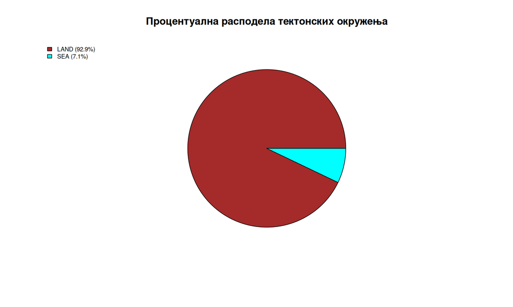

```r
tectonic_setting_data <- table(cleaned_data$LAND.OR.SEA) / nrow(cleaned_data)
colors <- c("brown", "cyan")

pie(
  tectonic_setting_data,
  col = colors,
  labels = NA,
  main = "Процентуална расподела тектонских окружења"
)

legend(
  "topleft",
  legend = paste0(names(tectonic_setting_data), " (", round(100 * tectonic_setting_data / sum(tectonic_setting_data), 1), "%)"),
  fill = colors,
  cex = 0.7,
  bty = "n"
)
```

2. У табели испод можемо видети исту информацију, овај пут са конкретним бројем стена у сваком окружењу. Дакле у скупу података постоји неуравнотеженост што се тиче тектонских окружења.

```r
tectonic_setting_data <- table(cleaned_data$LAND.OR.SEA)
tectonic_setting_data <- as.data.frame(tectonic_setting_data)
colnames(tectonic_setting_data) <- c("LAND.OR.SEA", "COUNT")

tectonic_setting_data$PERCENT <- round(tectonic_setting_data$COUNT / sum(tectonic_setting_data$COUNT) * 100, 2)
tectonic_setting_data <- tectonic_setting_data[order(tectonic_setting_data$COUNT), ]
tectonic_setting_data
```

```
##   LAND.OR.SEA  COUNT PERCENT
## 2         SEA  62286    7.12
## 1        LAND 813108   92.88
```

3. Још једно централно обележје скупа података је обележје TECTONIC.SETTING. Има 11 могућих вредности и представља мало детаљнију поделу тектонских окружења од поделе коју даје обележје LAND.OR.SEA. И овде можемо уочити неуравнотеженост где неколико вредности доминира у скупу.

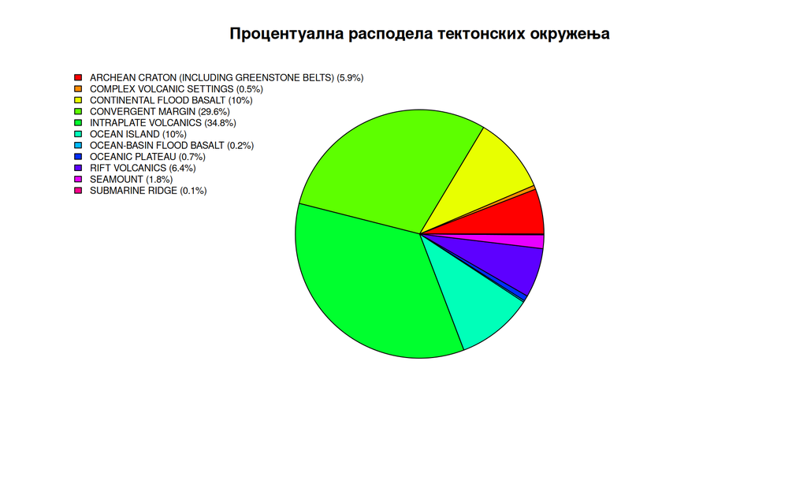

```r
tectonic_setting_data <- table(cleaned_data$TECTONIC.SETTING) / nrow(cleaned_data)
colors <- rainbow(length(tectonic_setting_data))

pie(
  tectonic_setting_data,
  col = colors,
  labels = NA,
  main = "Процентуална расподела тектонских окружења"
)

legend(
  "topleft",
  legend = paste0(names(tectonic_setting_data), " (", round(100 * tectonic_setting_data / sum(tectonic_setting_data), 1), "%)"),
  fill = colors,
  cex = 0.7,
  bty = "n"
)
```

4. У графику и табели испод можемо видети исту информацију, овај пут са конкретним бројем стена у сваком окружењу. Дакле у скупу података постоји неуравнотеженост што се тиче тектонских окружења.

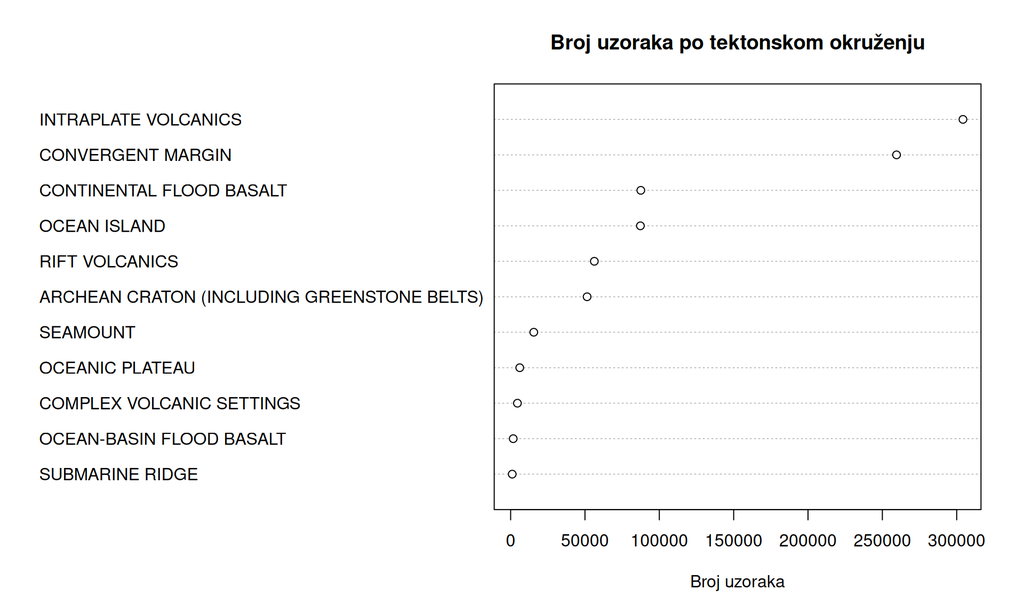

```r
tectonic_setting_data <- table(cleaned_data$TECTONIC.SETTING)
tectonic_setting_data <- sort(tectonic_setting_data, decreasing = FALSE)

labels <- names(tectonic_setting_data)

dotchart(
  tectonic_setting_data,
  labels = labels,
  main = "Broj uzoraka po tektonskom okruženju",
  xlab = "Broj uzoraka",
  cex = 1
)
```

```r
tectonic_setting_data <- as.data.frame(tectonic_setting_data)
colnames(tectonic_setting_data) <- c("TECTONIC.SETTING", "COUNT")

tectonic_setting_data$PERCENT <- round(tectonic_setting_data$COUNT / sum(tectonic_setting_data$COUNT) * 100, 2)
tectonic_setting_data <- tectonic_setting_data[order(tectonic_setting_data$COUNT), ]
tectonic_setting_data
```

```
##                               TECTONIC.SETTING  COUNT PERCENT
## 1                              SUBMARINE RIDGE   1080    0.12
## 2                     OCEAN-BASIN FLOOD BASALT   1743    0.20
## 3                    COMPLEX VOLCANIC SETTINGS   4575    0.52
## 4                              OCEANIC PLATEAU   6137    0.70
## 5                                     SEAMOUNT  15559    1.78
## 6  ARCHEAN CRATON (INCLUDING GREENSTONE BELTS)  51427    5.87
## 7                               RIFT VOLCANICS  56291    6.43
## 8                                 OCEAN ISLAND  87275    9.97
## 9                     CONTINENTAL FLOOD BASALT  87546   10.00
## 10                           CONVERGENT MARGIN 259553   29.65
## 11                        INTRAPLATE VOLCANICS 304208   34.75
```

5. Након централних обележја скупа података потребно је осврнути се и на остала, хемијска обележја. Испод се налази помоћна променљива која се користи у деловима кода где је могуће приказати податке везане за само једно обележје.

```r
chemical_column <- "SIO2.WT"
```

6. За почетак је потребно видети у ком проценту су недостајуће вредности заступљене у одабраном обележју.

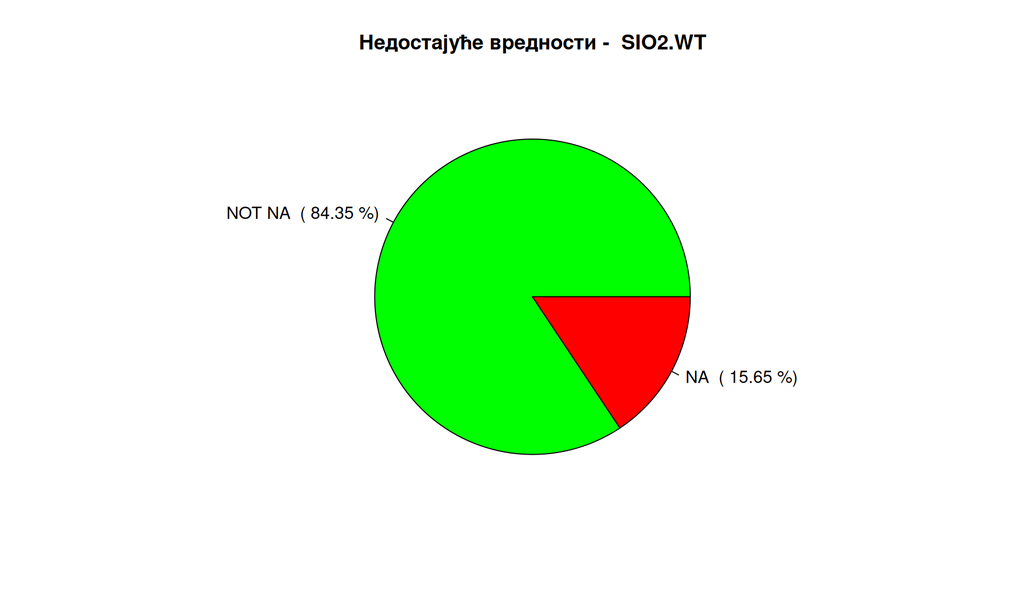

```r
missing_values_counts <- table(is.na(cleaned_data[[chemical_column]]))

labels <- c("NOT NA", "NA")
colors <- c("green", "red")

pie(
  missing_values_counts,
  labels = paste(labels, " (", round(100 * missing_values_counts / sum(missing_values_counts), 2), "%)"),
  col = colors,
  main = paste("Недостајуће вредности - ", chemical_column)
)
```

7. Затим, потребно је видети колико су недостајуће вредности одабраног обележја заступљене груписано по тектонским окружењима за поделу по обележју LAND.OR.SEA.

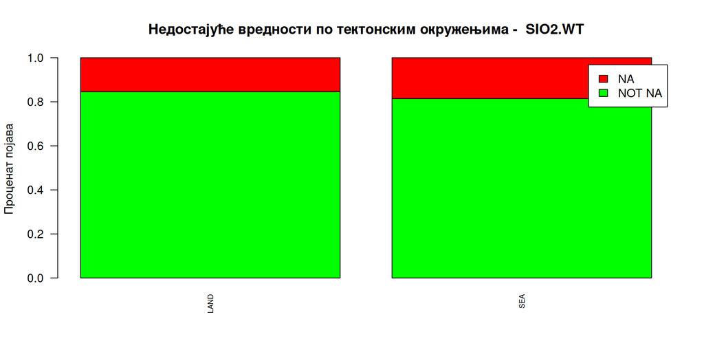

```r
missing_value_counts <- table(cleaned_data$LAND.OR.SEA, is.na(cleaned_data[[chemical_column]]))
missing_value_counts <- prop.table(missing_value_counts, 1)
missing_value_counts <- t(missing_value_counts)

labels <- c("NOT NA", "NA")
colors <- c("green", "red")

barplot(
  missing_value_counts,
  col = colors,
  legend = labels,
  beside = FALSE,
  las = 2,
  cex.names = 0.625,
  main = paste("Недостајуће вредности по тектонским окружењима - ", chemical_column),
  ylab = "Проценат појава"
)
```

7. Исту информацију могуће је видети у табели испод, овај пут са конкретним бројевима појава.

```r
chemical_data <- tapply(cleaned_data[[chemical_column]], cleaned_data$LAND.OR.SEA, function(x) sum(!is.na(x)))
chemical_data
```

```
##   LAND    SEA
## 687655  50722
```

8. Затим, потребно је видети колико су недостајуће вредности одабраног обележја заступљене груписано по тектонским окружењима за поделу по обележју TECTONIC.SETTING.

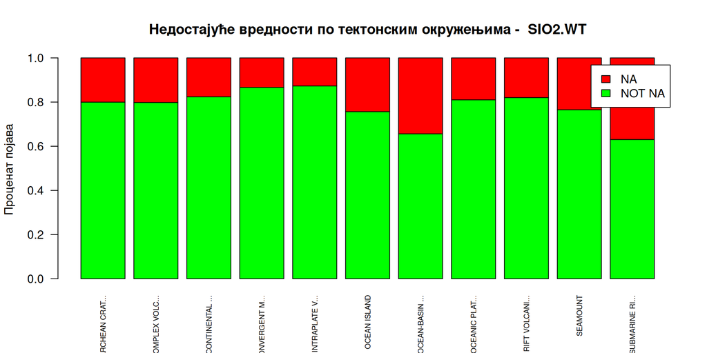

```r
missing_value_counts <- table(cleaned_data$TECTONIC.SETTING, is.na(cleaned_data[[chemical_column]]))
missing_value_counts <- prop.table(missing_value_counts, 1)
rownames(missing_value_counts) <- ifelse(
  nchar(rownames(missing_value_counts)) > 12,
  paste0(substr(rownames(missing_value_counts), 1, 12), "..."),
  rownames(missing_value_counts)
)
missing_value_counts <- t(missing_value_counts)

labels <- c("NOT NA", "NA")
colors <- c("green", "red")

barplot(
  missing_value_counts,
  col = colors,
  legend = labels,
  beside = FALSE,
  las = 2,
  cex.names = 0.625,
  main = paste("Недостајуће вредности по тектонским окружењима - ", chemical_column),
  ylab = "Проценат појава"
)
```

9. Исту информацију могуће је видети на графику испод, овај пут са конкретним бројевима појава.

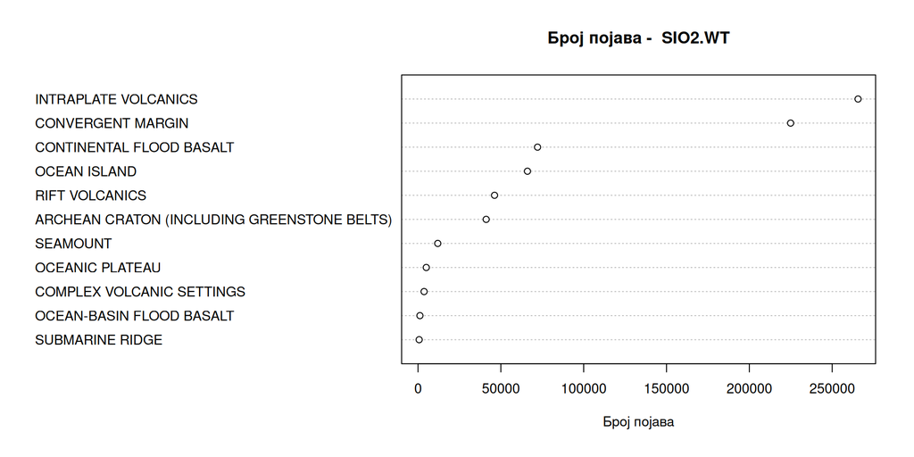

```r
chemical_data <- tapply(cleaned_data[[chemical_column]], cleaned_data$TECTONIC.SETTING, function(x) sum(!is.na(x)))
chemical_data <- sort(chemical_data, decreasing = FALSE)

dotchart(
  chemical_data,
  labels = names(chemical_data),
  main = paste("Број појава - ", chemical_column),
  xlab = "Број појава",
  cex = 0.9
)
```

10. Следеће што је потребно да се урадити је одређивање неких основних статистика. У табели испод су приказани минимум, максимум, просечна вредност, стандардна девијација и медијан за одабрано хемијско обележје.

```r
chemical_data <- cleaned_data[[chemical_column]]

chemical_data_summary <- data.frame(
  min = min(chemical_data, na.rm = TRUE),
  max = max(chemical_data, na.rm = TRUE),
  mean = mean(chemical_data, na.rm = TRUE),
  sd = sd(chemical_data, na.rm = TRUE),
  median = median(chemical_data, na.rm = TRUE)
)
chemical_data_summary
```

```
##   min max   mean       sd median
## 1   0 100 55.692 11.58411  53.41
```

11. Исте информације налазе се у табели испод, али су овај пут груписано по тектонском окружењу (LAND.OR.SEA).

```r
chemical_data <- select(cleaned_data, LAND.OR.SEA, all_of(chemical_column))

chemical_data_summary <- chemical_data %>%
  group_by(LAND.OR.SEA) %>%
  summarise(
    min = min(.data[[chemical_column]], na.rm = TRUE),
    max = max(.data[[chemical_column]], na.rm = TRUE),
    mean = mean(.data[[chemical_column]], na.rm = TRUE),
    sd = sd(.data[[chemical_column]], na.rm = TRUE),
    median = median(.data[[chemical_column]], na.rm = TRUE),
    .groups = "drop"
  )

chemical_data_summary
```

```
## # A tibble: 2 × 6
##   LAND.OR.SEA   min   max  mean    sd median
##   <fct>       <dbl> <dbl> <dbl> <dbl>  <dbl>
## 1 LAND         0    100    55.8 11.7    53.7
## 2 SEA          0.49  93.3  54.1  9.51   50.9
```

11. Исте информације налазе се у табели испод, али су овај пут груписано по тектонском окружењу (TECTONIC.SETTING).

```r
chemical_data <- select(cleaned_data, TECTONIC.SETTING, all_of(chemical_column))

chemical_data_summary <- chemical_data %>%
  group_by(TECTONIC.SETTING) %>%
  summarise(
    min = min(.data[[chemical_column]], na.rm = TRUE),
    max = max(.data[[chemical_column]], na.rm = TRUE),
    mean = mean(.data[[chemical_column]], na.rm = TRUE),
    sd = sd(.data[[chemical_column]], na.rm = TRUE),
    median = median(.data[[chemical_column]], na.rm = TRUE),
    .groups = "drop"
  )

chemical_data_summary
```

```
## # A tibble: 11 × 6
##    TECTONIC.SETTING                              min   max  mean    sd median
##    <fct>                                       <dbl> <dbl> <dbl> <dbl>  <dbl>
##  1 ARCHEAN CRATON (INCLUDING GREENSTONE BELTS)  0.01  99.8  54.3 11.6    51.4
##  2 COMPLEX VOLCANIC SETTINGS                   15.4   97.4  49.0  5.84   48.4
##  3 CONTINENTAL FLOOD BASALT                     0     96.3  50.7 11.4    50.1
##  4 CONVERGENT MARGIN                            0    100    58.4  8.55   56.9
##  5 INTRAPLATE VOLCANICS                         0     99.5  56.9 13.2    55.4
##  6 OCEAN ISLAND                                 0     98.4  49.8  7.16   49.0
##  7 OCEAN-BASIN FLOOD BASALT                     5.99  92.8  49.2  5.38   49.3
##  8 OCEANIC PLATEAU                             27.7   93.3  50.4  5.82   49.3
##  9 RIFT VOLCANICS                               0     99.8  56.0 14.8    51.8
## 10 SEAMOUNT                                     0.49  80.5  50.5  7.19   49.1
## 11 SUBMARINE RIDGE                             32.2   73.2  47.9  5.85   49.4
```

12. Затим је потребно визуализовати расподелу вредности. На кутијастом графикону испод може се видети расподела вредности за одабрано обележје.

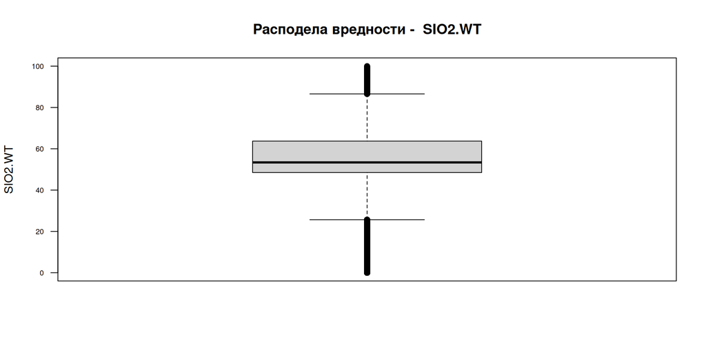

```r
chemical_data <- cleaned_data[[chemical_column]]

boxplot(
  chemical_data,
  main = paste("Расподела вредности - ", chemical_column),
  xlab = NA,
  ylab = chemical_column,
  las = 2,
  cex.axis = 0.625
)
```

11. Исте информације налазе се на кутијастом графикону испод, али су овај пут груписано по тектонском окружењу (LAND.OR.SEA).

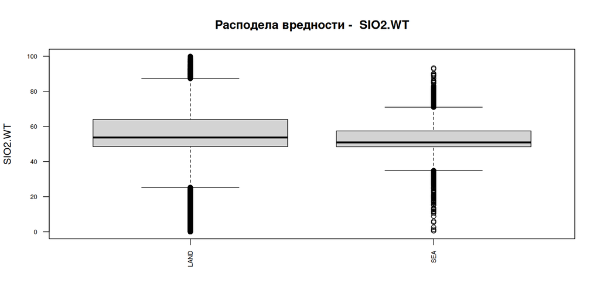

```r
chemical_data <- select(cleaned_data, LAND.OR.SEA, all_of(chemical_column))
chemical_data <- mutate(
    chemical_data,
    LAND.OR.SEA = ifelse(
      nchar(as.character(LAND.OR.SEA)) > 12,
      paste0(substr(as.character(LAND.OR.SEA), 1, 12), "..."),
      as.character(LAND.OR.SEA)
    )
  )

boxplot(
  chemical_data[[chemical_column]] ~ chemical_data$LAND.OR.SEA,
  main = paste("Расподела вредности - ", chemical_column),
  xlab = NA,
  ylab = chemical_column,
  las = 2,
  cex.axis = 0.625
)
```

12. Исте информације налазе се на кутијастом графикону испод, али су овај пут груписано по тектонском окружењу (TECTONIC.SETTING).

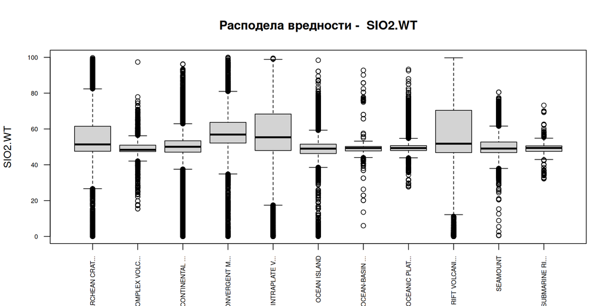

```r
chemical_data <- select(cleaned_data, TECTONIC.SETTING, all_of(chemical_column))
chemical_data <- mutate(
    chemical_data,
    TECTONIC.SETTING = ifelse(
      nchar(as.character(TECTONIC.SETTING)) > 12,
      paste0(substr(as.character(TECTONIC.SETTING), 1, 12), "..."),
      as.character(TECTONIC.SETTING)
    )
  )

boxplot(
  chemical_data[[chemical_column]] ~ chemical_data$TECTONIC.SETTING,
  main = paste("Расподела вредности - ", chemical_column),
  xlab = NA,
  ylab = chemical_column,
  las = 2,
  cex.axis = 0.625
)
```

13. Расподелу вредности је могуће приказати и на другачији начин, употребом хистограма. На хистограму испод може се видети расподела вредности за одабрано обележје.

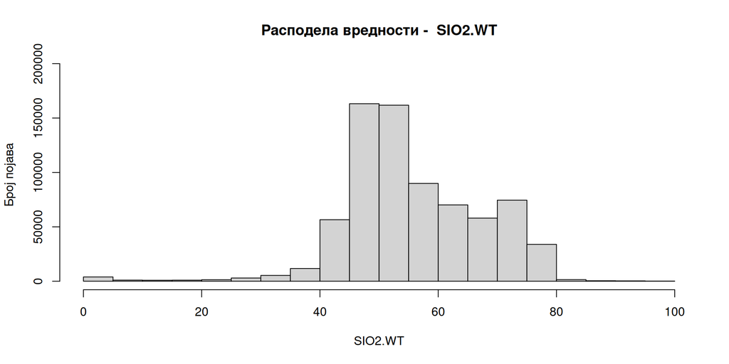

```r
h <- hist(cleaned_data[[chemical_column]], plot = FALSE)

hist(
  cleaned_data[[chemical_column]],
  main = paste("Расподела вредности - ", chemical_column),
  xlab = chemical_column,
  ylab = "Број појава",
  ylim = c(0, max(h$counts) * 1.2)
)
```

```r
cor(cleaned_data$SIO2.WT,
    cleaned_data$MGO.WT,
    use = "complete.obs")
```

```
## [1] -0.5568417
```

14. Након визуализације засебних обележја потребно је и испитати у каквом су међусобном односу. За почетак можемо утврдити какав је однос између различитих подела тектонских окружења (LAND.OR.SEA и TECTONIC.SETTING). На графикону испод можемо видети да већина класа из обележја TECTONIC.SETTING већински припада једној од класа из обележја LAND.OR.SEA. Само једна од 11 класа одступа од овог правила и донекле равномерно је подељена између копнених и морских тектонских окружења. Закључак који можемо извести из овога је да можда нема смисла користити оба обележја у оквиру класификационих модела јер имају јаку и очигледну међусобну везу.

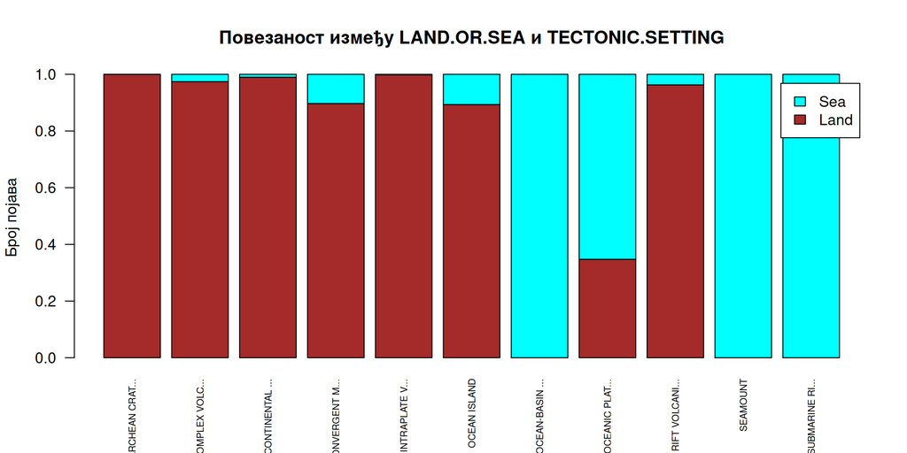

```r
corealtions <- table(cleaned_data$TECTONIC.SETTING, cleaned_data$LAND.OR.SEA)
corealtions <- prop.table(corealtions, 1)
rownames(corealtions) <- ifelse(
  nchar(rownames(corealtions)) > 12,
  paste0(substr(rownames(corealtions), 1, 12), "..."),
  rownames(corealtions)
)
corealtions <- t(corealtions)

labels <- c("Land", "Sea")
colors <- c("brown", "cyan")

barplot(
  corealtions,
  col = colors,
  legend = labels,
  beside = FALSE,
  las = 2,
  cex.names = 0.625,
  main = "Повезаност између LAND.OR.SEA и TECTONIC.SETTING",
  ylab = "Број појава"
)
```

```r
corelations <- cor(cleaned_data[chemical_columns], use = "pairwise.complete.obs")
corelations <- as.data.frame(as.table(corelations))
corelations <- corelations[corelations$Var1 != corelations$Var2, ]

corelations$key <- apply(corelations[, 1:2], 1, function(x) paste(sort(x), collapse = "_"))
corelations <- corelations[!duplicated(corelations$key), ]
corelations$key <- NULL

corelations <- corelations[order(abs(corelations$Freq), decreasing = TRUE), ]

colnames(corelations) <- c("Обележје 1", "Обележје 2", "Корелација")
corelations
```

```
##       Обележје 1 Обележје 2    Корелација
## 27          O.WT    SIO2.WT -1.000000e+00
## 129         O.WT    TIO2.WT -1.000000e+00
## 237        F.PPM    B2O3.WT  1.000000e+00
## 273       SN.PPM    B2O3.WT -1.000000e+00
## 277       CS.PPM    B2O3.WT -1.000000e+00
## 295        W.PPM    B2O3.WT  1.000000e+00
## 333         O.WT   AL2O3.WT -1.000000e+00
## 537         O.WT   FE2O3.WT -1.000000e+00
## 741         O.WT     CAO.WT  1.000000e+00
## 843         O.WT     MGO.WT  1.000000e+00
## 945         O.WT     MNO.WT  1.000000e+00
## 1149        O.WT     K2O.WT -1.000000e+00
## 1251        O.WT    NA2O.WT -1.000000e+00
## 1557        O.WT     CO2.WT -1.000000e+00
```

[output cut: 5137 more lines]

16. Ради лакшег фирлтрирања табеле, користимо помоћне променљиве да бисмо лакше пронашли корелацију која нас занима.

```r
chemical_column_1 <- "SIO2.WT"
chemical_column_2 <- "AL2O3.WT"

filter(
  corelations,
  (`Обележје 1` == chemical_column_1 & `Обележје 2` == chemical_column_2) |
  (`Обележје 1` == chemical_column_2 & `Обележје 2` == chemical_column_1)
)
```

```
##   Обележје 1 Обележје 2 Корелација
## 1   AL2O3.WT    SIO2.WT  0.2426797
```

## Класификација

### Класификација - Random Forest

Испод је приказана функција коришћена за Random Forest класификацију.

```r
run_random_forest <- function(predictor_columns, importance = TRUE, ...) {
  library(randomForest)
  library(caret)

  model_data <- cleaned_data[, c("LAND.OR.SEA", predictor_columns)]

  model_data[predictor_columns] <- lapply(
    model_data[predictor_columns],
    function(x) {
      x[is.na(x)] <- 0
      x
    }
  )

  set.seed(67)

  cross_validation <- trainControl(
    method = "cv",
    number = 2,
    classProbs = TRUE,
    savePredictions = TRUE
  )

  random_forest <- train(
    LAND.OR.SEA ~ .,
    data = model_data,
    method = "rf",
    trControl = cross_validation,
    importance = importance,
    tuneGrid = data.frame(mtry = floor(sqrt(length(predictor_columns)))),
    ...
  )

  if (importance) {
    print(importance(random_forest$finalModel))
  }

  print(random_forest)

  predictions <- random_forest$pred
  confusion_matrix_land <- confusionMatrix(predictions$pred, predictions$obs, positive = "LAND")
  confusion_matrix_sea <- confusionMatrix(predictions$pred, predictions$obs, positive = "SEA")

  accuracy <- confusion_matrix_land$overall["Accuracy"]
  land_precision <- confusion_matrix_land$byClass["Pos Pred Value"]
  land_sensitivity <- confusion_matrix_land$byClass["Sensitivity"]
  land_f1 <- 2 * (land_precision * land_sensitivity) / (land_precision + land_sensitivity)
  sea_precision <- confusion_matrix_sea$byClass["Pos Pred Value"]
  sea_sensitivity <- confusion_matrix_sea$byClass["Sensitivity"]
  sea_f1 <- 2 * (sea_precision * sea_sensitivity) /(sea_precision + sea_sensitivity)

  cat("\nМатрица конфузије:")
  print(confusion_matrix_land$table)

  cat("\nТачност:", accuracy)

  cat("\n\nLAND:")
  cat("\nПрецизност:", land_precision)
  cat("\nОсетљивост:", land_sensitivity)
  cat("\nСкор Ф1:", land_f1)

  cat("\n\nSEA:")
  cat("\nПрецизност:", sea_precision)
  cat("\nОсетљивост:", sea_sensitivity)
  cat("\nСкор Ф1:", sea_f1)
}
```

### Класификација - Random Forest 1 (RF1)

```r
predictor_columns <- c(oxide_columns, trace_element_columns)

run_random_forest(
  predictor_columns = predictor_columns,
  ntree = 10
)
```

```
##                LAND          SEA MeanDecreaseAccuracy MeanDecreaseGini
## SIO2.WT  17.6375457 12.884450244            18.432582     4.041259e+03
## TIO2.WT  10.6526112  7.599817674            10.442530     3.781344e+03
## B2O3.WT   0.0000000  0.000000000             0.000000     1.411765e-04
## AL2O3.WT  8.0891120  8.916889240            13.729842     4.203150e+03
## CR2O3.WT 14.2294969  6.662121389            13.769258     2.200796e+02
## FE2O3.WT 13.6798726 13.855184463            16.884572     1.483498e+03
## FEO.WT    7.2514712  8.130066299             7.638715     1.353246e+03
## CAO.WT    9.9746998 10.606204306            10.824464     4.418377e+03
## MGO.WT   15.0568642 11.262007307            14.938603     3.607308e+03
## MNO.WT   14.9075122 13.474292499            14.909280     2.511035e+03
## NIO.WT    4.4223412  4.021064533             6.568316     1.631178e+02
## K2O.WT   12.8451407  6.007294859            10.212578     4.986260e+03
## NA2O.WT   9.8189807  6.849640984             8.687222     3.644688e+03
## P2O5.WT  10.0021412 16.744091831            13.735636     2.939804e+03
## H2O.WT    9.8510791 16.051501826            14.400652     7.435613e+02
## CO2.WT    6.2806220 14.286465762             8.999386     8.087113e+02
## CO1.WT    2.0701956  2.581907154             2.673490     3.558635e+00
## F.WT      7.0125760  7.529973210             9.682884     2.788418e+02
## CL.WT     7.9849234  9.201143190             9.305948     1.435180e+03
## CL2.WT    3.6022286  8.289176392             7.272432     7.654791e+01
## OH.WT     3.3927803  4.004421618             5.634124     3.122965e+01
## CH4.WT    1.0540926  1.054092553             1.054093     3.109039e+00
## SO2.WT    4.7803237  7.882707682             7.356363     2.802743e+02
## SO3.WT    7.8343558 10.732869185            13.434691     2.792215e+02
## SO4.WT    0.0000000  0.000000000             0.000000     1.014860e-01
## S.WT      7.3232874 10.359712769            10.930301     9.875292e+02
## O.WT      0.0000000  0.000000000             0.000000     0.000000e+00
## LI.PPM   19.7399905  9.483591731            19.526450     7.581591e+02
## BE.PPM    8.0332956 13.576810431            10.786052     2.845966e+02
## B.PPM     8.4016406  9.942189987             9.858891     3.979105e+02
## C.PPM     4.5987778  4.514621694             5.011516     6.086693e+01
## CO2.PPM   6.6965158  7.428873578             8.567599     4.056238e+02
## F.PPM     5.2815157  4.363511887             6.639711     1.659742e+02
## NA.PPM    2.2630299  2.878395386             2.758690     2.434062e+01
## MG.PPM    2.8831616  3.583816496             3.115887     6.820203e+01
## AL.PPM    2.3469118  3.660616951             2.961508     3.020020e+01
## P.PPM     7.0079852  4.176978969             5.956029     1.185836e+02
## S.PPM     6.6486041  6.082220259             7.134238     9.810585e+02
## CL.PPM    7.3954246  8.439812753             8.451453     1.356454e+03
```

[output cut: 80 more lines]

```
## Prediction   LAND    SEA
##       LAND 811807  22313
##       SEA    1301  39973
##
## Тачност: 0.9730247
##
## LAND:
## Прецизност: 0.9732497
## Осетљивост: 0.9984
## Скор Ф1: 0.9856644
##
## SEA:
## Прецизност: 0.9684789
## Осетљивост: 0.6417654
## Скор Ф1: 0.7719776
```

### Класификација - Random Forest 2 (RF2)

```r
predictor_columns <- c(oxide_columns, trace_element_columns)

run_random_forest(
  predictor_columns = predictor_columns,
  importance = FALSE,
  ntree = 20,
  classwt = c(LAND = 1, SEA = 2)
)
```

```
## Random Forest
##
## 875394 samples
##    102 predictor
##      2 classes: 'LAND', 'SEA'
##
## No pre-processing
## Resampling: Cross-Validated (2 fold)
## Summary of sample sizes: 437697, 437697
## Resampling results:
##
##   Accuracy   Kappa
##   0.9311476  0.5903334
##
## Tuning parameter 'mtry' was held constant at a value of 10
##
## Матрица конфузије:          Reference
## Prediction   LAND    SEA
##       LAND 764657  11822
##       SEA   48451  50464
##
## Тачност: 0.9311476
##
## LAND:
## Прецизност: 0.9847749
## Осетљивост: 0.9404126
## Скор Ф1: 0.9620826
##
## SEA:
## Прецизност: 0.5101754
## Осетљивост: 0.8101981
## Скор Ф1: 0.6261003
```

### Класификација - Random Forest 3 (RF3)

```r
predictor_columns <- c(
  "ZR.PPM",
  "MGO.WT",
  "MO.PPM",
  "P2O5.WT",
  "CR2O3.WT",
  "K2O.WT",
  "ZN.PPM",
  "CU.PPM",
  "SIO2.WT",
  "TI.PPM",
  "H2O.WT",
  "B.PPM",
  "CO.PPM",
  "HF.PPM",
  "CL.WT",
  "S.WT",
  "RB.PPM",
  "SR.PPM",
  "NB.PPM",
  "BA.PPM"
)

run_random_forest(
  predictor_columns = predictor_columns,
  importance = FALSE,
  ntree = 30,
  classwt = c(LAND = 1, SEA = 1.05)
)
```

```
## Random Forest
##
## 875394 samples
##     20 predictor
##      2 classes: 'LAND', 'SEA'
##
## No pre-processing
## Resampling: Cross-Validated (2 fold)
## Summary of sample sizes: 437697, 437697
## Resampling results:
##
##   Accuracy   Kappa
##   0.8972406  0.4673473
##
## Tuning parameter 'mtry' was held constant at a value of 4
##
## Матрица конфузије:          Reference
## Prediction   LAND    SEA
##       LAND 737134  13981
##       SEA   75974  48305
##
## Тачност: 0.8972406
##
## LAND:
## Прецизност: 0.9813863
## Осетљивост: 0.9065635
## Скор Ф1: 0.9424922
##
## SEA:
## Прецизност: 0.3886819
## Осетљивост: 0.7755354
## Скор Ф1: 0.5178356
```